# Introduction to `wbstats` package in R

Stefani Langehennig

21/05/2020

## Easy access to the World Bank API

This is a brief tutorial on accessing the World Bank data through the `wbstats` package in R, which provides access to all statistics and data files housed on the their website [here](http://data.worldbank.org/developers/api-overview) and associated [data catalogue](http://data.worldbank.org/developers/data-catalog-api) through their API. This is a tremendously helpful and straightforward tool for analysts and data scientists wishing to access global data that span decades and contain numerous socio-economic indicators.[^1]

In addition to easy accessibility to data that would otherwise take a lot of time to gather, the package includes a variety of helpful functions to help analyse the data once collected from the API. Taken together, the wbstats package allows for reproducibility and automation of otherwise cumbersome tasks with larger datasets.

Highlights from the package include:

- The ability to query and retrieve data based on country
- The ability to query and retrieve data from different languages[^2]
- Compatility with other R packages (grepl, dplyr, ggplot2, etc.)

For more information on all of the great features for the package, see the [official documentation](https://cran.r-project.org/web/packages/wbstats/wbstats.pdf) that largely guided this tutorial.

### Downloading packages

Before getting started, we need to download the requisite `wbstat` package into R. For this tutorial, we will first need to install the wbstats package and then import that library into our current working directory.

```r
#install.packages("wbstats")
library(wbstats)
```

### General overview of the data

To get a general feel for the World Bank data, the package provides the option of pulling in cached data from the API, which gives a useful list of the information we can access. Together with the `str` function, we can use the `wb_cachelist` function to grab the top level of data coming from the API. Looks like there are a handful of interesting data frames to work with!

```r
str(wb_cachelist, max.level = 1)
```

```
## List of 7
##  $ countries  :'data.frame': 304 obs. of  18 variables:
##  $ indicators :'data.frame': 16978 obs. of  7 variables:
##  $ sources    :'data.frame': 43 obs. of  8 variables:
##  $ datacatalog:'data.frame': 238 obs. of  29 variables:
##  $ topics     :'data.frame': 21 obs. of  3 variables:
##  $ income     :'data.frame': 7 obs. of  3 variables:
##  $ lending    :'data.frame': 4 obs. of  3 variables:
```

To get the most most up-to-date data in the cache list from the API, you can create an empty object and use the `wbcache` function. Note: the default language is English, so we will use that here. You can specify another language using the `lang` parameter.

```r
#wb_cache <- wbcache()
```

### Querying indicators

The first thing we need to do is identify our indicators of interest. The `wbsearch()` function sifts through all of the indicators available from the World Bank API. There is an abundance of information that is returned when this function is called, including the description of the indicator, its source, and the associated name/id.

```r
poverty_vars <- wbsearch(pattern = "poverty")

# let's take a look at the first few observations
head(poverty_vars)
```

```
##        indicatorID
## 820 SH.UHC.NOP2.ZS
## 821 SH.UHC.NOP2.ZG
## 822 SH.UHC.NOP2.TO
## 823 SH.UHC.NOP2.CG
## 824 SH.UHC.NOP1.ZS
## 825 SH.UHC.NOP1.ZG
##                                                                                                                       indicator
## 820      Proportion of population pushed below the $3.10 ($ 2011 PPP) poverty line by out-of-pocket health care expenditure (%)
## 821 Increase in poverty gap at $3.10 ($ 2011 PPP) poverty line due to out-of-pocket health care expenditure (% of poverty line)
## 822                  Number of people pushed below the $3.10 ($ 2011 PPP) poverty line by out-of-pocket health care expenditure
## 823               Increase in poverty gap at $3.10 ($ 2011 PPP) poverty line due to out-of-pocket health care expenditure (USD)
## 824      Proportion of population pushed below the $1.90 ($ 2011 PPP) poverty line by out-of-pocket health care expenditure (%)
## 825 Increase in poverty gap at $1.90 ($ 2011 PPP) poverty line due to out-of-pocket health care expenditure (% of poverty line)
```

```r
# specifying "sourceOrg" as an additional field of interest
poverty_vars2 <- wbsearch(pattern = "poverty", fields = c("sourceOrg"))
```

Another feature of the `wbsearch` function is its compatibility with regex. This allows you to search for multiple strings (e.g. words) using the `pattern` parameter to match on strings in the indicators. This will return indicators with these words in them.

```r
povempledu_vars <- wbsearch(pattern = "poverty|employment|education")
head(povempledu_vars)
```

```
##                    indicatorID
## 2  XGDP.56.FSGOV.FDINSTADM.FFD
## 3  XGDP.23.FSGOV.FDINSTADM.FFD
## 9                    WP15184.7
## 10                   WP15184.6
## 27                 WP15177_3.7
## 28                 WP15177_3.6
##                                                                                                      indicator
## 2                                              Government expenditure in tertiary institutions as % of GDP (%)
## 3                                   Government expenditure in secondary institutions education as % of GDP (%)
## 9  Received payments for agricultural products in the past year, secondary education or more (% ages 15+) [w2]
## 10   Received payments for agricultural products in the past year, primary education or less (% ages 15+) [w2]
## 27              Used an account to receive government transfers, secondary education or more (% ages 15+) [w2]
## 28                Used an account to receive government transfers, primary education or less (% ages 15+) [w2]
```

### Pulling in the data

After we have identified the indicators we are interested in exploring/using, we can use the `wb` function to pull the actual data into R from the World Bank API. It defaults to all countries, which can be fine-tuned by calling the `country` function and specifying the countries you are most interested in.

Let’s take a look at the variable that captures CO2 emissions, `EN.ATM.CO2E.PC`, by creating an object that captures observations for that indicator from 1995 to 2015.

```r
co2_data <- wb(indicator = "EN.ATM.CO2E.PC", startdate = 1995, enddate = 2015)

head(co2_data)
```

```
##   iso3c date    value    indicatorID                              indicator
## 2   ARB 2014 4.886988 EN.ATM.CO2E.PC CO2 emissions (metric tons per capita)
## 3   ARB 2013 4.674925 EN.ATM.CO2E.PC CO2 emissions (metric tons per capita)
## 4   ARB 2012 4.837780 EN.ATM.CO2E.PC CO2 emissions (metric tons per capita)
## 5   ARB 2011 4.559462 EN.ATM.CO2E.PC CO2 emissions (metric tons per capita)
## 6   ARB 2010 4.636813 EN.ATM.CO2E.PC CO2 emissions (metric tons per capita)
## 7   ARB 2009 4.562015 EN.ATM.CO2E.PC CO2 emissions (metric tons per capita)
##   iso2c    country
## 2    1A Arab World
## 3    1A Arab World
## 4    1A Arab World
## 5    1A Arab World
## 6    1A Arab World
## 7    1A Arab World
```

```r
co2_gdp_data <- wb(country = c("US", "FR"), indicator = c("EN.ATM.CO2E.PC", "NY.GDP.MKTP.CD"),
                   startdate = 2000, enddate = 2015)

head(co2_gdp_data)
```

```
##   iso3c date    value    indicatorID                              indicator
## 2   FRA 2014 4.573460 EN.ATM.CO2E.PC CO2 emissions (metric tons per capita)
## 3   FRA 2013 5.062172 EN.ATM.CO2E.PC CO2 emissions (metric tons per capita)
## 4   FRA 2012 5.075062 EN.ATM.CO2E.PC CO2 emissions (metric tons per capita)
## 5   FRA 2011 5.077911 EN.ATM.CO2E.PC CO2 emissions (metric tons per capita)
## 6   FRA 2010 5.428981 EN.ATM.CO2E.PC CO2 emissions (metric tons per capita)
## 7   FRA 2009 5.438357 EN.ATM.CO2E.PC CO2 emissions (metric tons per capita)
##   iso2c country
## 2    FR  France
## 3    FR  France
## 4    FR  France
## 5    FR  France
## 6    FR  France
## 7    FR  France
```

Should your analyses necessitate, the data can also be returned in a wide format. This is done by specifying `return_wide=TRUE` in your query.

```r
co2_gdp_wide <- wb(country = c("US", "FR"), indicator = c("EN.ATM.CO2E.PC", "NY.GDP.MKTP.CD"),
                   startdate = 2000, enddate = 2015, return_wide = TRUE)

head(co2_gdp_wide)
```

```
##   iso3c date iso2c country EN.ATM.CO2E.PC NY.GDP.MKTP.CD
## 1   FRA 2000    FR  France       5.946665   1.362249e+12
## 2   FRA 2001    FR  France       6.153061   1.376465e+12
## 3   FRA 2002    FR  France       6.068664   1.494287e+12
## 4   FRA 2003    FR  France       6.115998   1.840481e+12
## 5   FRA 2004    FR  France       6.120079   2.115742e+12
## 6   FRA 2005    FR  France       6.099599   2.196126e+12
```

### Putting the data to work

Now that we have seen how to examine and pull in the data using the API, we can start doing some simple analyses. So far, we have worked with the GDP and CO2 emissions indicators. Let’s use a different indicator, `NY.GNP.PCAP.CD`, which captures the gross national income.

Let’s take a look at the GNI for France and Great Britain over a 12 year span.

```r
dat <- wb(country = c("FRA", "GBR"), indicator = "NY.GNP.PCAP.CD", mrv = 12)
head(dat)
```

```
##   iso3c date value    indicatorID                                  indicator
## 1   FRA 2018 41090 NY.GNP.PCAP.CD GNI per capita, Atlas method (current US$)
## 2   FRA 2017 38330 NY.GNP.PCAP.CD GNI per capita, Atlas method (current US$)
## 3   FRA 2016 39070 NY.GNP.PCAP.CD GNI per capita, Atlas method (current US$)
## 4   FRA 2015 41100 NY.GNP.PCAP.CD GNI per capita, Atlas method (current US$)
## 5   FRA 2014 43320 NY.GNP.PCAP.CD GNI per capita, Atlas method (current US$)
## 6   FRA 2013 43780 NY.GNP.PCAP.CD GNI per capita, Atlas method (current US$)
##   iso2c country
## 1    FR  France
## 2    FR  France
## 3    FR  France
## 4    FR  France
## 5    FR  France
## 6    FR  France
```

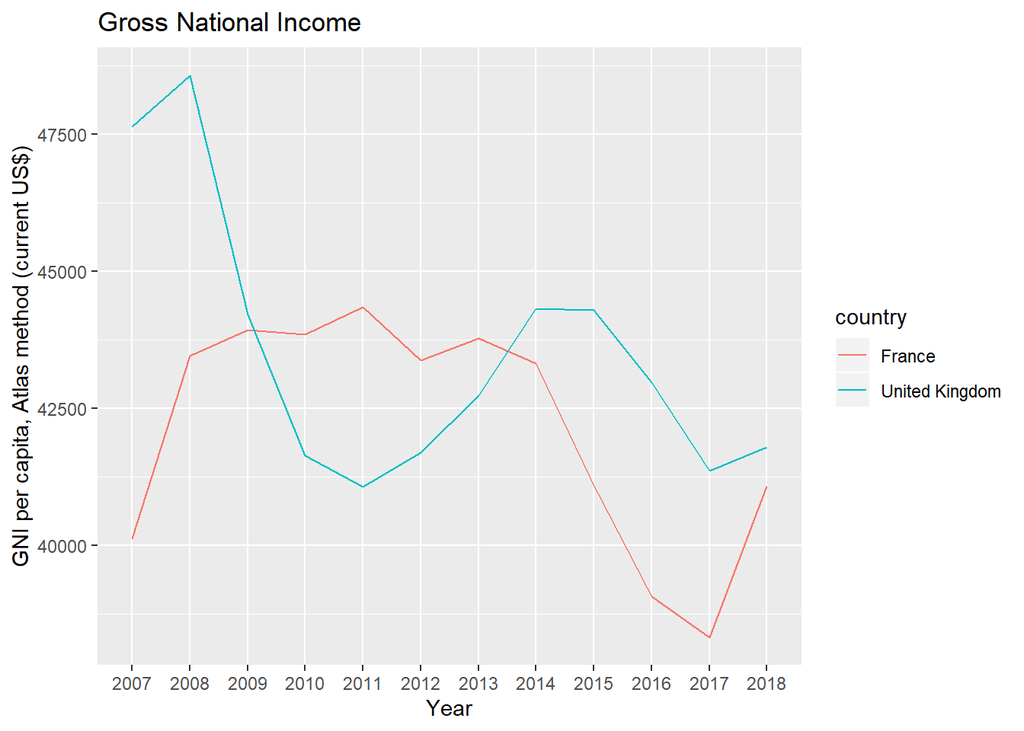

```r
library(ggplot2)

ggplot(dat, aes(x = date, y = value)) + geom_line(aes(colour = country, group = country)) +
 labs(title = "Gross National Income", x = "Year", y = "GNI per capita, Atlas method (current US$)")
```

### **BONUS**: Using R Markdown? Embed a searchable table of results[^3]

As an added bonus, we can embed the results of our queries in a data table in our document. The `DT` package in R lets you do this very easily. The output can be tailored to show as many lines from the results as you wish, includes a search bar, and provides the option to filter, to name a few.

Let’s embed a table of results for our `co2_gdp_wide` object so we can allow readers of our document to quickly access statistics for their year, country, and indicator of choice. We can also export the data that we retrieve in our data table by including the option to ‘copy’ or put into a .csv, .pdf, etc. file extension.

```r
library(DT)

datatable(co2_gdp_wide, rownames = FALSE, filter="top", extensions = 'Buttons', options = list(pageLength = 5, scrollX=T, dom = 'Bfrtip', buttons = c('copy', 'csv', 'excel', 'pdf', 'print')))
```

| iso3c | date | iso2c | country | EN.ATM.CO2E.PC | NY.GDP.MKTP.CD |
| --- | --- | --- | --- | --- | --- |
| FRA | 2000 | FR | France | 5.94666546275395 | 1362248940482.77 |
| FRA | 2001 | FR | France | 6.1530605991809 | 1376465324384.79 |
| FRA | 2002 | FR | France | 6.06866447158945 | 1494286655373.61 |
| FRA | 2003 | FR | France | 6.11599810786062 | 1840480812641.08 |
| FRA | 2004 | FR | France | 6.12007856802886 | 2115742488204.62 |
| FRA | 2005 | FR | France | 6.09959885469542 | 2196126103718.44 |
| FRA | 2006 | FR | France | 5.90626638550961 | 2318593651988.46 |
| FRA | 2007 | FR | France | 5.76638534996401 | 2657213249384.07 |
| FRA | 2008 | FR | France | 5.69050185705677 | 2918382891460.38 |
| FRA | 2009 | FR | France | 5.43835706284818 | 2690222283967.77 |

[output cut: 22 more lines]

### Conclusion

The World Bank API provides a wealth of data that is publicly accessible and very useful to researchers and analysts who need quick summary statistics of socio-economic situations across the world. The `wbstats` package has made it much easier to download, query, and visualise these data by creating a number of functions that remove the heavy lifting normally associated with these tasks. We have only scratched the tip of the iceberg when it comes to using the package. I encourage everyone to dig deeper into the documentaton and play around with all of the capabiltiies it includes.

[^1]: This tutorial assumes users have familiarity and basic knowledge of R.
[^2]: Support across the different languages varies: some are are very well supported, while others are limited. Be diligent in checking for `NAs` when using different languages in the dataset.
[^3]: This only works for dynamic, not static, documents such as html. If you choose to knit your file to a PDF or Word document, the `DT` functionalities do not work.